# Matching sensor overlap

Jose Eduardo Meireles

## The problem

Instruments may measure different spectral ranges using different detectors, resulting in abrupt “jumps” in the reflectance or radiance data. In such cases, the regions between sensors need to be matched, i.e. spliced together. Unmatched spectra collected with a 3-sensor instrument, such as the SVC HR1024, may look like this:

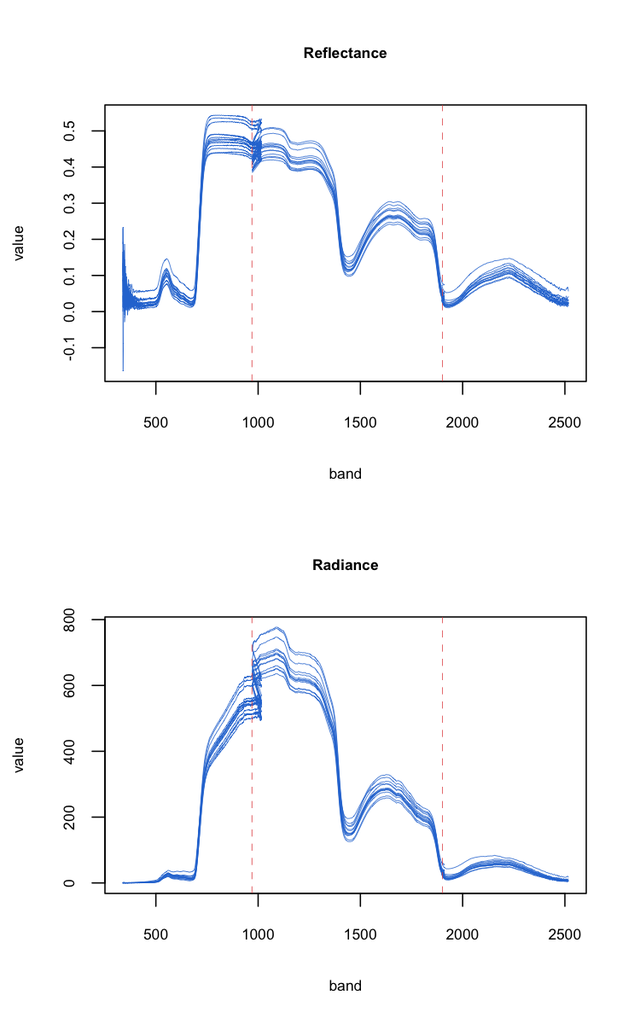

```r
# Path to raw (unmatched) spectra
path_raw = system.file("extdata/svc_raw_and_overlap_matched_serbin/SVC_Files/",
                       package = "spectrolab")

# Read spectra as reflectance and radiance
reflect_raw  = read_spectra(path = path_raw, type = "target_reflectance")

radiance_raw = read_spectra(path = path_raw, type = "target_radiance")

# Detector crossovers marked with vertical dashed lines (this file's own
# header records 970 and 1901 nm -- see "Where do the splice points come from?")
lwd = 0.5
cex = 0.7

oldpar = par(no.readonly = TRUE)
par(mfrow = c(2, 1))

plot(reflect_raw, main = "Reflectance", col = spec_pal[1],
     lwd = lwd, cex.main = cex, cex.lab = cex, cex.axis = cex)
abline(v = c(970, 1901), col = spec_pal[6], lty = 2, lwd = lwd)

plot(radiance_raw, main = "Radiance", col = spec_pal[1],
     lwd = lwd, cex.main = cex, cex.lab = cex, cex.axis = cex)
abline(v = c(970, 1901), col = spec_pal[6], lty = 2, lwd = lwd)
```

```r
par(oldpar)
```

Every instrument – and every *vendor* – handles this differently: SVC **deletes** the overlapping points after matching one detector to the other, Spectral Evolution/NaturaSpec **ramp-blends** across the overlap, and ASD ships data that is *already* joined (it only records where the splice happened, not how). `spectrolab` has **one** function for all of them, `match_sensors()`, and one algorithm behind it.

## Where do the splice points come from?

`read_spectra()` captures per-sample provenance about the detector splice at read time – into the `sensor_info(x)` attribute – whenever the source file records it:

```r
sensor_info(reflect_raw)[1:2, ]
```

```
#>   instrument splice_1 splice_2 match_lo match_hi
#> 1        svc       NA       NA       NA       NA
#> 2        svc       NA       NA       NA       NA
```

Here the file records no splice wavelengths (`splice_1`/`splice_2` are `NA`): this particular SVC file was saved *before* on-board splicing, so you must supply `splice_at` yourself (or estimate it, see below). Files saved by the instrument *after* splicing *do* record the splice wavelengths, and `match_sensors(x)` will use them automatically without any arguments – see Provenance-aware defaults.

You can use `plot_interactive()` to zoom into a particular spectral region and decide what the `splice_at` values should be. You can also use the function `guess_splice_at()` to estimate these bands for you, but keep in mind that these are **guesses**.

```r
# Spectrolab's guess of what the splice bands are.
# However, you should also visually inspect the spectra to determine what the
# boundaries between sensors are.
splice_bands_guess = guess_splice_at(reflect_raw)
splice_bands_guess
```

```
#> [1]  986.7333 1901.1000
```

```r
# Finally, if you know what those sensor bounds should be (say, they're given by
# the manufacturer, or read off the instrument's own header), use those numbers
# instead of spectrolab's guess. This file's own header records 970/1901 (see
# sensor_info() of the matched reference file below) rather than the nominal
# 990/1900 from the manual -- always prefer what the file says over the manual.
splice_bands = c(970, 1901)
```

[output not shown]

## Matching the sensors

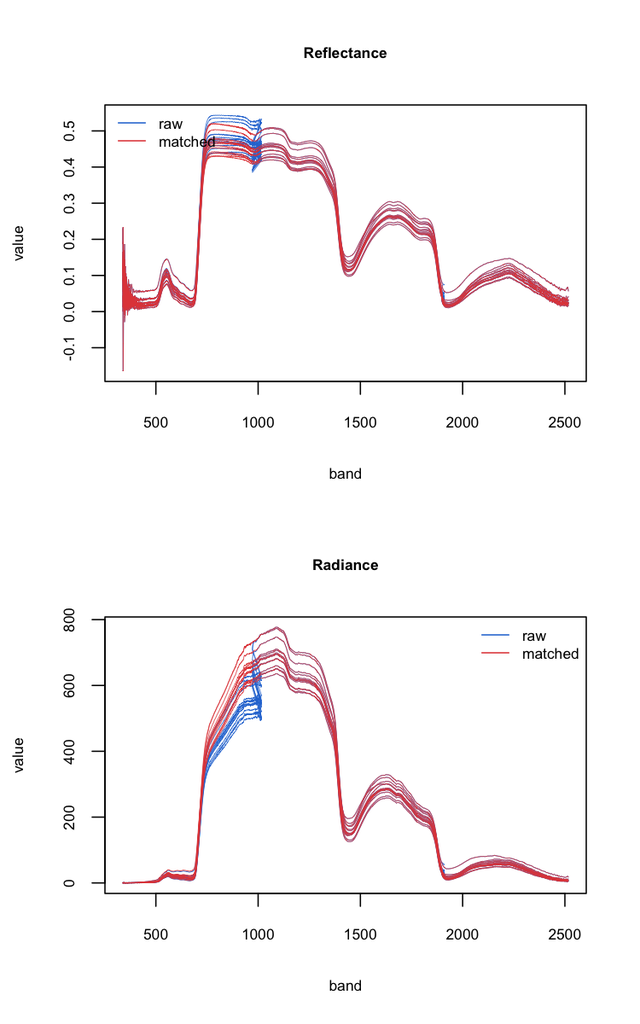

```r
# Match the reflectance and radiance data
reflect_matched  = match_sensors(x = reflect_raw,  splice_at = splice_bands)

radiance_matched = match_sensors(x = radiance_raw, splice_at = splice_bands)

lwd = 0.5
cex = 0.7

oldpar = par(no.readonly = TRUE)

par(mfrow = c(2, 1))

plot(reflect_raw, main = "Reflectance", col = spec_pal[1],
     lwd = lwd, cex.main = cex, cex.lab = cex, cex.axis = cex)
plot(reflect_matched, col = spec_pal[6], add = TRUE, lwd = lwd)
legend("topleft", legend = c("raw", "matched"),
       col = spec_pal[c(1, 6)], lwd = 1, bty = "n", cex = cex)

plot(radiance_raw, main = "Radiance", col = spec_pal[1],
     lwd = lwd, cex.main = cex, cex.lab = cex, cex.axis = cex)
plot(radiance_matched, col = spec_pal[6], add = TRUE, lwd = lwd)
legend("topright", legend = c("raw", "matched"),
       col = spec_pal[c(1, 6)], lwd = 1, bty = "n", cex = cex)
```

```r
par(oldpar)
```

## How close is that to the instrument’s own splice?

Close enough to measure, because this example ships the *same 14 scans twice*: raw, and reprocessed by SVC’s own software. The vendor’s file is ground truth.

```r
path_moc = system.file("extdata/svc_raw_and_overlap_matched_serbin/SVC_Files_moc/",
                       package = "spectrolab")

reflect_moc = read_spectra(path = path_moc, type = "target_reflectance")

# same 982 bands the vendor kept -- the overlap was removed the same way
identical(bands(reflect_matched), bands(reflect_moc))
```

```
#> [1] TRUE
```

```r
# and the values land on the vendor's
rmse = function(fit, vendor, lo = -Inf, hi = Inf){
    k   = match(round(bands(vendor), 4), round(bands(fit), 4))
    sel = bands(vendor) >= lo & bands(vendor) <= hi
    sqrt(mean((value(fit)[, k[sel]] - value(vendor)[, sel])^2))
}

round(c(overall    = rmse(reflect_matched, reflect_moc),
        detector_1 = rmse(reflect_matched, reflect_moc, hi = 969),
        detector_2 = rmse(reflect_matched, reflect_moc, lo = 970, hi = 1900),
        detector_3 = rmse(reflect_matched, reflect_moc, lo = 1901)), 6)
```

```
#>    overall detector_1 detector_2 detector_3
#>   0.000129   0.000152   0.000145   0.000002
```

For scale: cutting the overlap without any magnitude matching leaves an overall RMSE of 0.0077 against the same reference, roughly sixty times larger. Detector 1 carries the correction; detector 2 is touched only where it is crossfaded into detector 1; detector 3 comes through the join untouched, exactly as the vendor’s does (its residual is one band out of 3,570, differing by a single unit of the file’s own rounding). The residuals are at the level of the two decimal places the `.sig` files store, and they are small because each of the three steps was measured against these files – the taper’s shape, the crossfade, and the way the gain amplitude is estimated were all chosen that way.

Overlaying raw, matched, and the vendor’s reference – with a zoom on the first splice – shows where the work goes:

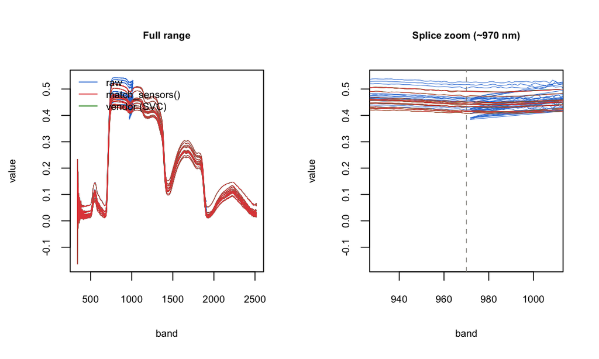

```r
lwd = 0.6
cex = 0.7

col_raw     = spec_pal[1]   # blue   -- raw, unmatched
col_matched = spec_pal[6]   # red    -- spectrolab
col_vendor  = spec_pal[4]   # green  -- vendor (SVC) matched reference

oldpar = par(no.readonly = TRUE)
par(mfrow = c(1, 2))

# --- Full range -----------------------------------------------------------
plot(reflect_raw, main = "Full range", col = col_raw,
     lwd = lwd, cex.main = cex, cex.lab = cex, cex.axis = cex)
plot(reflect_moc,     col = col_vendor,  add = TRUE, lwd = lwd)
plot(reflect_matched, col = col_matched, add = TRUE, lwd = lwd)
legend("topleft", legend = c("raw", "match_sensors()", "vendor (SVC)"),
       col = c(col_raw, col_matched, col_vendor), lwd = 1, bty = "n", cex = cex)

# --- Splice zoom (first junction, ~970 nm) --------------------------------
plot(reflect_raw, main = "Splice zoom (~970 nm)", col = col_raw,
     xlim = c(930, 1010), lwd = lwd,
     cex.main = cex, cex.lab = cex, cex.axis = cex)
plot(reflect_moc,     col = col_vendor,  add = TRUE, lwd = lwd)
plot(reflect_matched, col = col_matched, add = TRUE, lwd = lwd)
abline(v = 970, col = spec_muted, lty = 2, lwd = lwd)
```

```r
par(oldpar)
```

## Provenance-aware defaults

Because `read_spectra()` records splice provenance, `match_sensors(x)` with no `splice_at` at all does the sensible thing depending on what it finds:

- **Already spliced** (bands already strictly increasing, e.g. a standard ASD spectrum, or an SVC file saved in `"Remove"` mode after on-board splicing): returned unchanged, with a message – it’s a safe no-op, not silently re-splicing data that doesn’t need it.

```r
match_sensors(reflect_moc)
```

```
#> Bands are already strictly increasing; the sensor overlap appears to have been spliced already. Returning spectra unchanged.
#> spectra object
#> number of samples: 14
#> bands: 338.2 to 2517.2 (982 bands)
#> metadata: none
#> instrument: svc
#>
#>                      338.2  339.7  341.1  342.6  344.1  345.5  347     ...
#> BNL13001_000_moc.sig 0.0855 0.0943 0.088  0.107  0.0507 0      0.0287
#> BNL13001_001_moc.sig 0.0122 0.0707 0.11   0.0535 0.1015 0.0997 0.0215
#> BNL13002_000_moc.sig 0.1344 0.0825 0.121  0.0892 0.1269 0.0614 0.0932
#> BNL13002_001_moc.sig 0.0978 -0.165 -0.088 0.107  0.1692 0.1227 -0.0287
#> BNL13002_002_moc.sig 0.0978 0.165  0.1649 0.1337 0.0507 0.046  0.1004
```

- **Splice points on file** (an SVC file saved in `"Remove"` mode records where it cut): those wavelengths are used automatically.
- **Nothing recorded and nothing supplied** (our raw `"Preserve"`-mode file above): a clear error asking you to supply `splice_at`, rather than a guess.

```r
match_sensors(reflect_raw)
```

```
#> Error:
#> ! No `splice_at` supplied and no splice points found in the sensor provenance (see sensor_info(x)). Provide `splice_at` explicitly, e.g. from guess_splice_at(x).
```

## Gotchas

- **This is not a bit-exact replay of vendor firmware.** SVC applies its matching factor to the reference *and* target radiance with slightly different values, so the correction does not fully cancel out of a single reflectance column the way it does inside the instrument’s own software. `spectrolab` reproduces the *removal* structure exactly and applies a correct, general gain – it does not claim to reproduce vendor reflectance byte-for-byte. And SVC is the only vendor that ships a reference to check against: on ASD or Spectral Evolution data this is spectrolab’s own, documented correction, not the instrument’s. See `?match_sensors`.
- **`interpolate_wvl` only matters when the detectors do not overlap.** When they do, the overlap itself is the crossover window (inset off both ends, where detector response rolls off), which is a measurement rather than a guess. `interpolate_wvl` is the fallback for already-joined data, where there is nothing to measure.
- **Only the first junction is gain-matched when the detectors overlap.** The far crossover of a 3-detector instrument sits near 1900 nm, inside the deep water band where both detectors are at the edge of their sensitivity; a factor estimated there is noise, and applying it ramps a large error across a whole detector. SVC’s own software makes the same call – it removes both overlaps but matches only the near one.
- **Order of `splice_at` matters less than getting the values right.** `match_sensors()` sorts `splice_at` for you, but it cannot tell if you handed it the wrong wavelengths for *this* file – always cross-check against `sensor_info(x)` or a visual inspection rather than trusting a manual’s nominal crossover points (this file’s own header says 970/1901, not the SVC manual’s nominal 990/1900).
- **Everything downstream expects strictly increasing bands.** `smooth()`, `normalize()`, `resample()`, and the two-band spectral indices all check for this and will error on raw, unspliced data – run `match_sensors()` first.